# Habits of biowaste management of swiss people

Capstone Project

Author

Affiliation

Marc Sauter

[ETH Zurich](https://ethz.ch/de.html)

Published

June 5, 2025

```r
library(tidyverse)
library(gt)
library(gtsummary)
library(knitr)
library(DT)
library(ggplot2)
library(patchwork)

biowaste <- read_csv(here::here("data/processed/survey_data_cleaned.csv"))
```

# Introduction

As mentioned in Kaza et al. (2018) organic waste in landfills generates methane, a potent greenhouse gas (28 - 36x stronger than CO2 over 100 years). Failing to compost those organic wastes results in unnecessary greenhouse gas emissions and landfill leachate, which can contaminate groundwater and soil. Additionally you loose the advantage of composted bio waste which improves the soil structure, fertility, and microbial diversity (Ho et al. (2022)). Also incinerating bio waste is less efficient and more polluting than composting or anaerobic digestion according to Bernstad & La Cour Jansen (2012). Due to the high water content in food/bio waste reduces the combustion efficiency and increases flue gas emissions.

To gain an understanding in the habits of separating bio waste of swiss people, a survey is conducted in the context of the lecture “Research beyond the lab” at ETH Zurich.

# Methods

In order to obtain the needed data to make statements about the bio waste management behaviour of swiss people, a survey was used. This survey was created using the tool Google Forms. It was comprised of twelve to sixteen questions, depending on some answers chosen. Some answers to questions needed further questions to gather even more relevant information.

The survey was built up in two parts. The first part covered more general questions about the person answering the survey, such as age, gender, living situation, education, employment type and more. The second part was more focused on the (bio)waste aspect. Questions include information about whether bio waste was currently being recycled, how much bio waste was generated in the household per week in liters or what other solid wastes were recycled in the household.

The survey was shared online, the data collected was then processed using R with the tidyverse library.

# Results

In Table 1 an overview over the bio waste separation habits depending on the persons age can be seen. It is shown, that more people have a habit of separating bio wastes.

```r
biowaste_separation_age_tbl <- biowaste |>
  group_by(biowaste_separation) |>
  summarise(
    Count = n(),
    Mean = mean(age, na.rm = TRUE),
    sd = sd(age, na.rm =TRUE),
    Median = median(age, na.rm = TRUE),
    Min = min(age, na.rm =TRUE),
    Max = max(age, na.rm = TRUE)
  )


biowaste_separation_age_tbl |>
  gt() |>
  tab_header(title = "Bio waste separation depending on age") |>
  fmt_number(columns = Mean:sd, decimals = 2) |>
  cols_label(biowaste_separation = "Bio waste separation")
```

Table 1: Bio waste separation depending on age

Bio waste separation depending on age

| Bio waste separation | Count | Mean | sd | Median | Min | Max |
| --- | --- | --- | --- | --- | --- | --- |
| no | 5 | 22.20 | 1.30 | 23 | 20 | 23 |
| yes | 16 | 22.31 | 3.93 | 22 | 16 | 30 |

Figure 1 shows the general relationship between the household size and the separation habits of bio wastes. It can be seen that generally bigger households tend to not separate their bio waste. This could be explained by a lack of feeling responsible for the task in a bigger household.

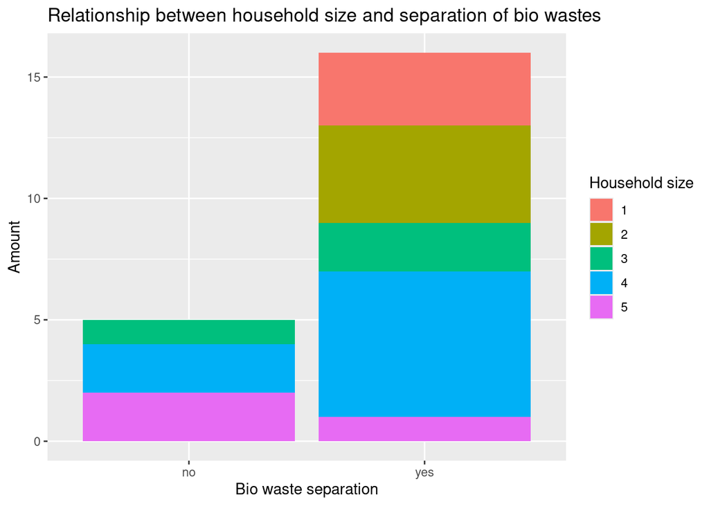

Figure 1: Relationship between the household size and the separation of bio wastes

```r
biowaste$household <- as.factor(biowaste$household)

ggplot(data = biowaste,
       mapping = aes(x = biowaste_separation,
                     fill = household)
       ) +
  geom_bar() +
  labs(title = "Relationship between household size and separation of bio wastes",
       x = "Bio waste separation",
       y = "Amount",
       fill = "Household size")
```

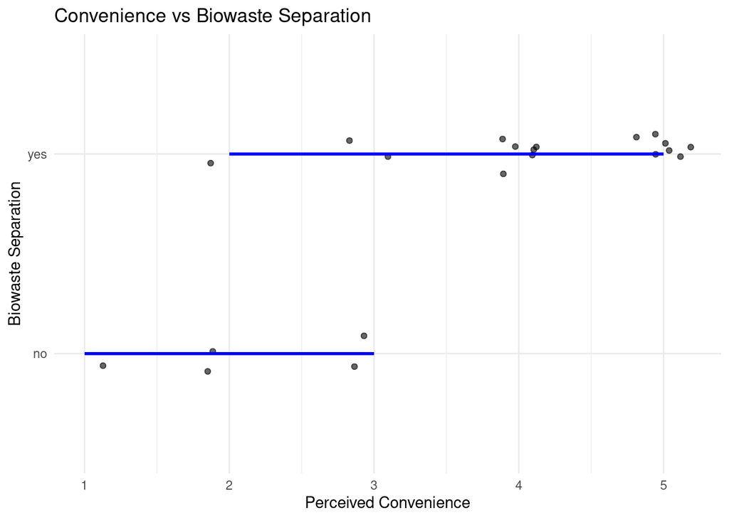

Figure 2: Relationship between the perceived convenience of already implemented bio waste management systems against the bio waste separation of the surveyed people.

```r
ggplot(data = biowaste, aes(x = biowaste_system_convenience,
                            y = biowaste_separation)) +
  geom_jitter(width = 0.2, height = 0.1, alpha = 0.6) +
  geom_smooth(method = "lm", se = FALSE, color = "blue") +
  labs(title = "Convenience vs Biowaste Separation",
       x = "Perceived Convenience",
       y = "Biowaste Separation") +
  theme_minimal()
```

From the respondents answering that they are not separating their bio waste, Figure 3 shows how they reacted to different improvement suggestions. The first suggestion was to introduce some sort of monetary incentive if people would start separating bio wastes. This was generally not as welcome as the second option, which was to improve the existing facilities, e.g. more frequent pick ups.

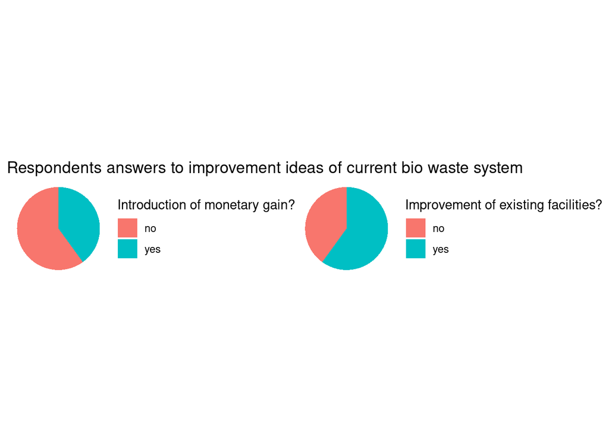

Figure 3: Relationships of peoples answers to the introduction of improvements to the current bio waste management. On the left hand side are the responses to a monetary gain, on the right hand side the responses to improving existing facilities.

```r
biowaste_done <- filter(biowaste, !is.na(biowaste_begin_monetary)) |>
  count(biowaste_begin_monetary) |>
  mutate(share_mon = n / sum(n),
         label = scales::percent(share_mon, accuracy = 1))



p1 <- ggplot(biowaste_done,
             aes(x = "",
                 y = share_mon,
                 fill = biowaste_begin_monetary)) +
  geom_col(width = 1) +
  coord_polar(theta = "y") +
  theme_void()+
  labs(title = "Respondents answers to improvement ideas of current bio waste system",
    fill = "Introduction of monetary gain?")


biowaste_done <- filter(biowaste, !is.na(biowaste_begin_facilities)) |>
  count(biowaste_begin_facilities) |>
  mutate(share_fac = n / sum(n),
         label = scales::percent(share_fac, accuracy = 1))


p2 <- ggplot(biowaste_done,
             aes(x = "",
                 y = share_fac,
                 fill = biowaste_begin_facilities)) +
  geom_col(width = 1) +
  coord_polar(theta = "y") +
  theme_void()+
  labs(fill = "Improvement of existing facilities?")


p1 + p2
```

However it has to be said, that only a total of five respondents didn’t already separate bio waste, meaning the sample size of people for improvement ideas is small and thus insignificant.

# Conclusion

- A large fraction of the people surveyed already separate bio waste from solid wastes.
- Larger households tend to lead to a lack in bio waste separation.
- The perceived convenience by the surveyed people coincides with the bio waste separation habits.
- From the people surveyed not separating bio wastes, a larger fraction prefers to improve existing facilities instead of introducing a monetary gain.
- However the sample size of people answering the questions about improvement ideas is too small to take not of any meaningful trend.

## References

Bernstad, A., & La Cour Jansen, J. (2012). Review of comparative LCAs of food waste management systems – current status and potential improvements. *Waste Management*, *32*(12), 2439–2455. https://doi.org/10.1016/j.wasman.2012.07.023

Ho, T. T. K., Tra, V. T., Le, T. H., Nguyen, N.-K.-Q., Tran, C.-S., Nguyen, P.-T., Vo, T.-D.-H., Thai, V.-N., & Bui, X.-T. (2022). Compost to improve sustainable soil cultivation and crop productivity. *Case Studies in Chemical and Environmental Engineering*, *6*, 100211. https://doi.org/10.1016/j.cscee.2022.100211

Kaza, S., Yao, L. C., Bhada-Tata, P., & Van Woerden, F. (2018). *What a waste 2.0: A global snapshot of solid waste management to 2050*. Washington, DC: World Bank. https://doi.org/10.1596/978-1-4648-1329-0